# RED WINE QUALITY DATA EXPLORATION by Jiffin James

This report explores the red wine quality dataset which contains 1,599 rows with 13 variables on the chemical properties of the wine.

# Univariate Plots Section

```
## [1] 1599   13
```

```
## 'data.frame':    1599 obs. of  13 variables:
##  $ X                   : int  1 2 3 4 5 6 7 8 9 10 ...
##  $ fixed.acidity       : num  7.4 7.8 7.8 11.2 7.4 7.4 7.9 7.3 7.8 7.5 ...
##  $ volatile.acidity    : num  0.7 0.88 0.76 0.28 0.7 0.66 0.6 0.65 0.58 0.5 ...
##  $ citric.acid         : num  0 0 0.04 0.56 0 0 0.06 0 0.02 0.36 ...
##  $ residual.sugar      : num  1.9 2.6 2.3 1.9 1.9 1.8 1.6 1.2 2 6.1 ...
##  $ chlorides           : num  0.076 0.098 0.092 0.075 0.076 0.075 0.069 0.065 0.073 0.071 ...
##  $ free.sulfur.dioxide : num  11 25 15 17 11 13 15 15 9 17 ...
##  $ total.sulfur.dioxide: num  34 67 54 60 34 40 59 21 18 102 ...
##  $ density             : num  0.998 0.997 0.997 0.998 0.998 ...
##  $ pH                  : num  3.51 3.2 3.26 3.16 3.51 3.51 3.3 3.39 3.36 3.35 ...
##  $ sulphates           : num  0.56 0.68 0.65 0.58 0.56 0.56 0.46 0.47 0.57 0.8 ...
##  $ alcohol             : num  9.4 9.8 9.8 9.8 9.4 9.4 9.4 10 9.5 10.5 ...
##  $ quality             : int  5 5 5 6 5 5 5 7 7 5 ...
```

```
##        X          fixed.acidity   volatile.acidity  citric.acid
##  Min.   :   1.0   Min.   : 4.60   Min.   :0.1200   Min.   :0.000
##  1st Qu.: 400.5   1st Qu.: 7.10   1st Qu.:0.3900   1st Qu.:0.090
##  Median : 800.0   Median : 7.90   Median :0.5200   Median :0.260
##  Mean   : 800.0   Mean   : 8.32   Mean   :0.5278   Mean   :0.271
##  3rd Qu.:1199.5   3rd Qu.: 9.20   3rd Qu.:0.6400   3rd Qu.:0.420
##  Max.   :1599.0   Max.   :15.90   Max.   :1.5800   Max.   :1.000
##  residual.sugar     chlorides       free.sulfur.dioxide
##  Min.   : 0.900   Min.   :0.01200   Min.   : 1.00
##  1st Qu.: 1.900   1st Qu.:0.07000   1st Qu.: 7.00
##  Median : 2.200   Median :0.07900   Median :14.00
##  Mean   : 2.539   Mean   :0.08747   Mean   :15.87
##  3rd Qu.: 2.600   3rd Qu.:0.09000   3rd Qu.:21.00
##  Max.   :15.500   Max.   :0.61100   Max.   :72.00
##  total.sulfur.dioxide    density             pH          sulphates
##  Min.   :  6.00       Min.   :0.9901   Min.   :2.740   Min.   :0.3300
##  1st Qu.: 22.00       1st Qu.:0.9956   1st Qu.:3.210   1st Qu.:0.5500
##  Median : 38.00       Median :0.9968   Median :3.310   Median :0.6200
##  Mean   : 46.47       Mean   :0.9967   Mean   :3.311   Mean   :0.6581
##  3rd Qu.: 62.00       3rd Qu.:0.9978   3rd Qu.:3.400   3rd Qu.:0.7300
##  Max.   :289.00       Max.   :1.0037   Max.   :4.010   Max.   :2.0000
##     alcohol         quality
##  Min.   : 8.40   Min.   :3.000
##  1st Qu.: 9.50   1st Qu.:5.000
##  Median :10.20   Median :6.000
##  Mean   :10.42   Mean   :5.636
##  3rd Qu.:11.10   3rd Qu.:6.000
##  Max.   :14.90   Max.   :8.000
```

Our dataset consists of 1599 observations with 13 variables.From the output of str function it is quite clear that all the variables are numeric.

Now we will plot some of the variables to understand it’s distribution.

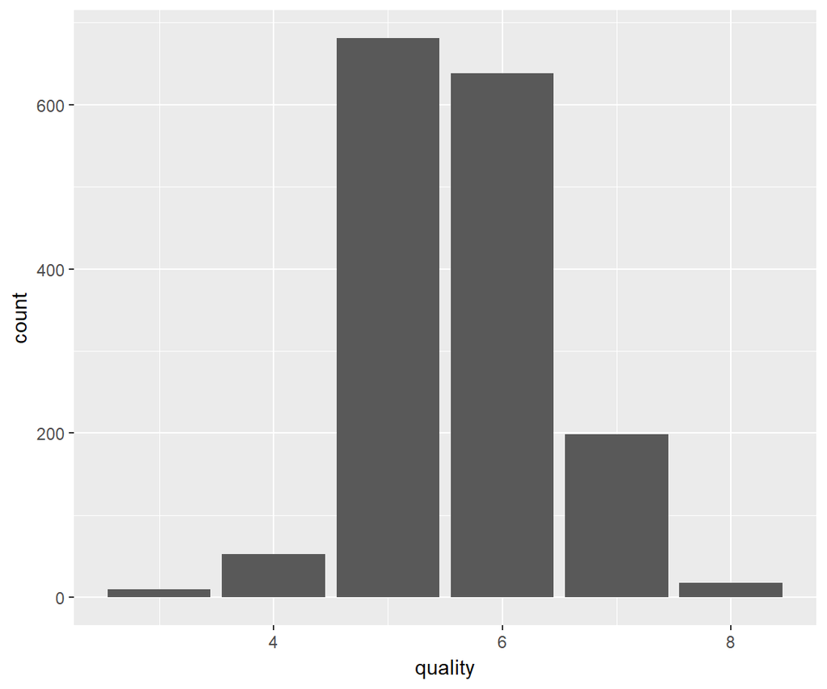

This shows that most of the observations have quality rating of 5 and 6.Since the data is normally distributed we will not apply any kind of transformation. Further Investigating quality we find-

```
##
##   3   4   5   6   7   8
##  10  53 681 638 199  18
```

The actual rating ranges from 0 to 10,but observations in our dataset contain 6 levels of quality(3-8).

Plotting other variables-

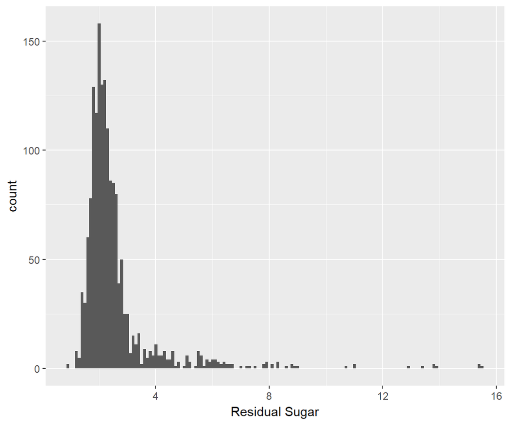

This plot looks right skewed.So we need to apply transformation.

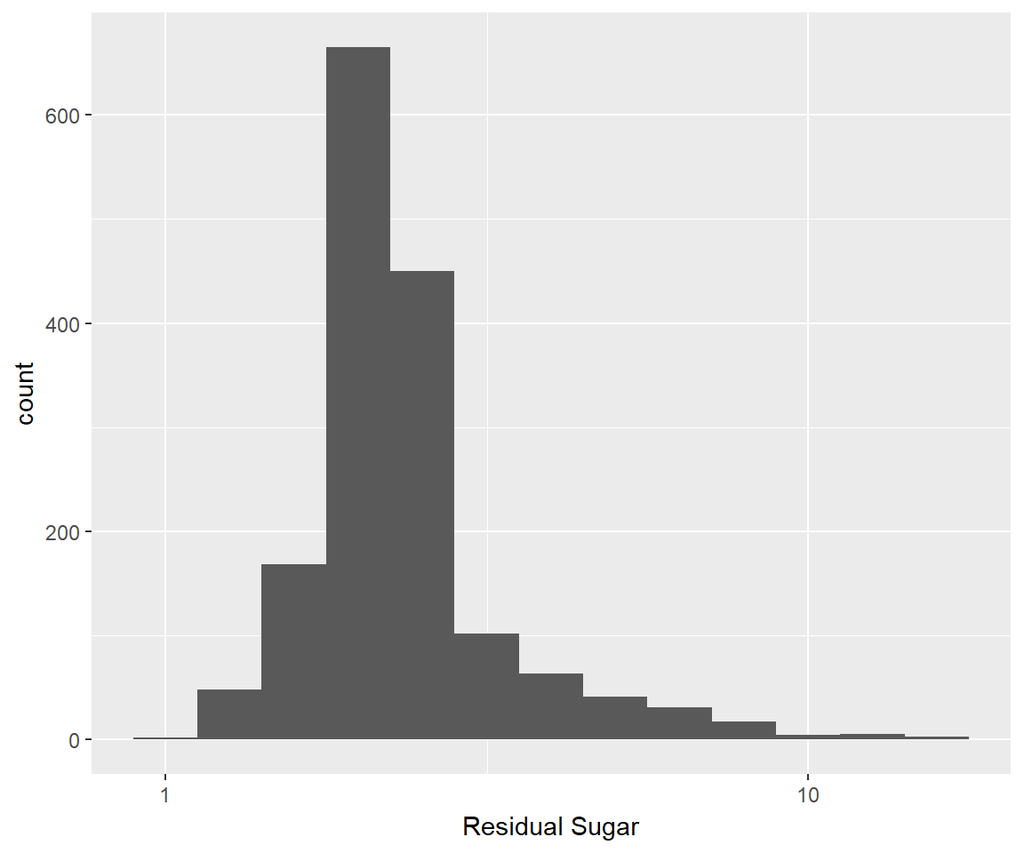

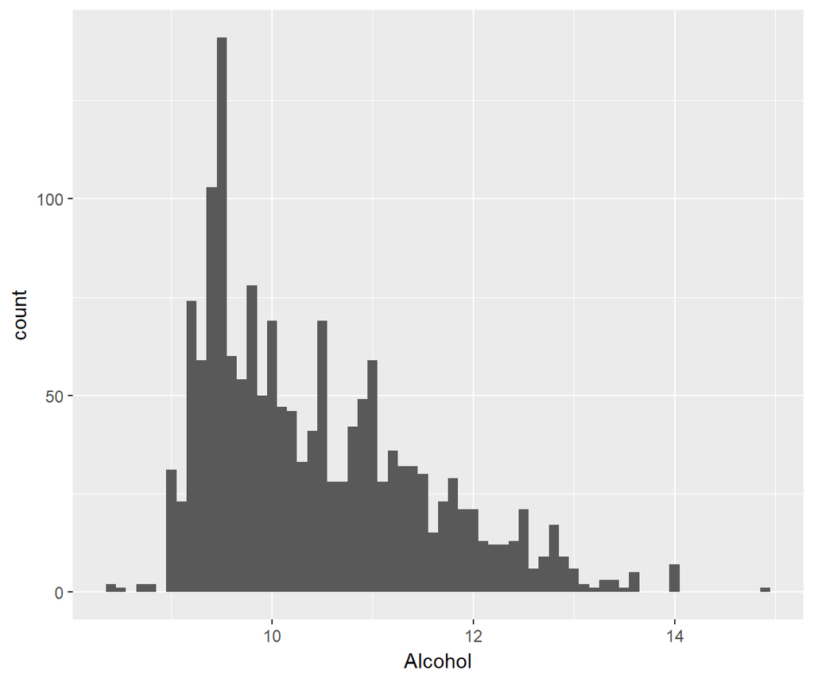

```
##    Min. 1st Qu.  Median    Mean 3rd Qu.    Max.
##    8.40    9.50   10.20   10.42   11.10   14.90
```

The above summary shows the various statistics about alcohol feature.

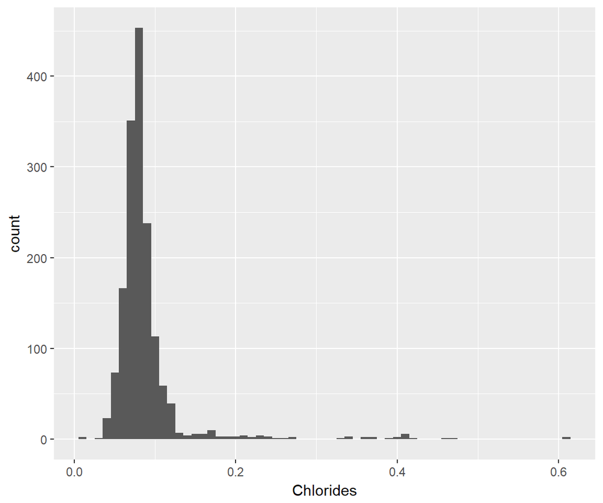

This clearly shows exitence of outlier towards the right end.Zooming in,we find that there indeed are some outliers because the summary says that around 75% of the data lies below 0.0900-

```
##    Min. 1st Qu.  Median    Mean 3rd Qu.    Max.
## 0.01200 0.07000 0.07900 0.08747 0.09000 0.61100
```

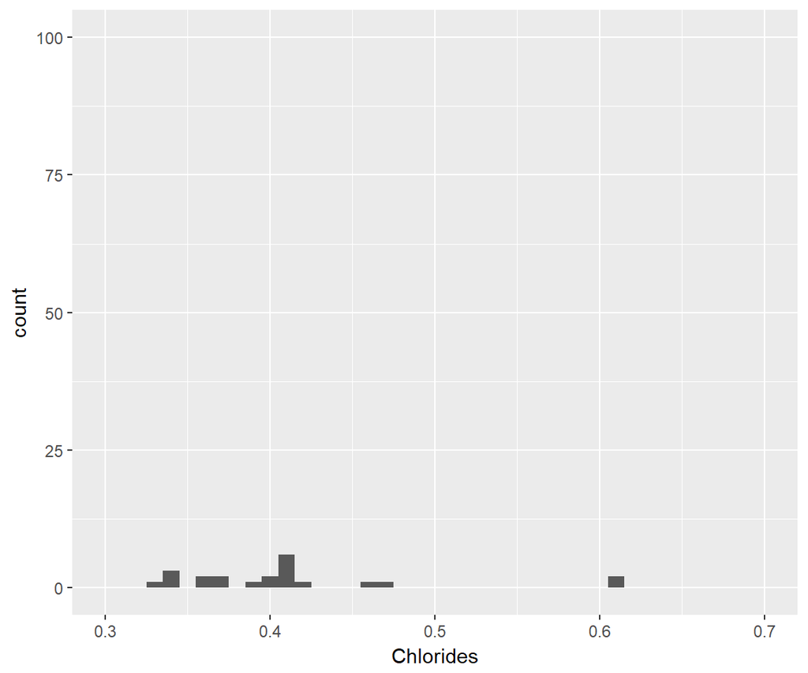

Exploring rest of the variables-

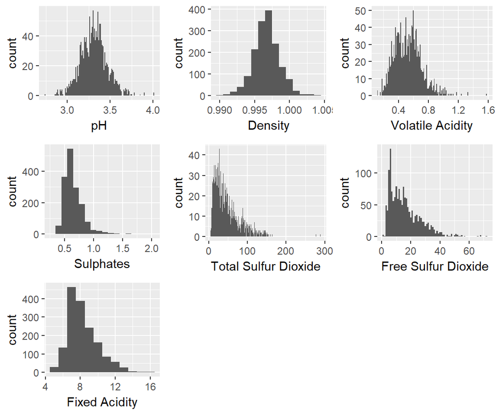

# Univariate Analysis

### What is the structure of your dataset?

- Most wine are rated 5 or 6.
- residual.sugar variable is skewed.
- chlorides variable has outliers.

### What is/are the main feature(s) of interest in your dataset?

The main feature of interest in this dataset is the Quality of wine(rating). I want to see which features affect the rating of wine.

### What other features in the dataset do you think will help support your investigation into your feature(s) of interest?

Features like residual.sugar,alcohol will help support my investigation into my feature of interest i.e wine quality.

### Did you create any new variables from existing variables in the dataset?

As of now I haven’t created any new variable

### Of the features you investigated, were there any unusual distributions? Did you perform any operations on the data to tidy, adjust, or change the form of the data? If so, why did you do this?

# Bivariate Plots Section

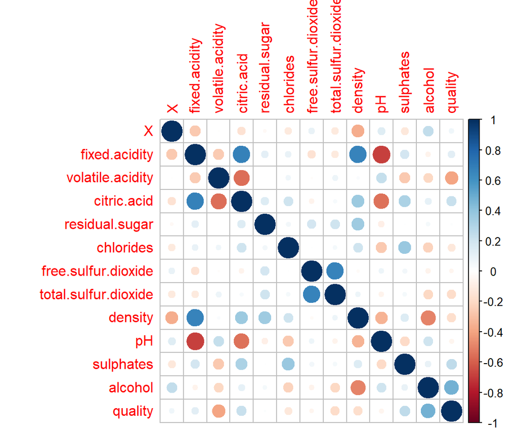

From the above correlation plot,it is quite clear that quality has some correlation with alcohol,sulphates,volatile.acidity and citric.acid. Though the correlation between quality and volatile.acidity among the above is negative,others have a positive correlation with quality.There are other correlation too like pH is strongly correlated(negative) with fixed.acidity, this can be explained by the fact that acids have lower pH and bases have higher pH values.This also explains why pH and citric.acid are correlated.

```
##      volatile.acidity citric.acid sulphates   alcohol
## [1,]       -0.3905578   0.2263725 0.2513971 0.4761663
```

So,we will look at some boxplots involving these variables.

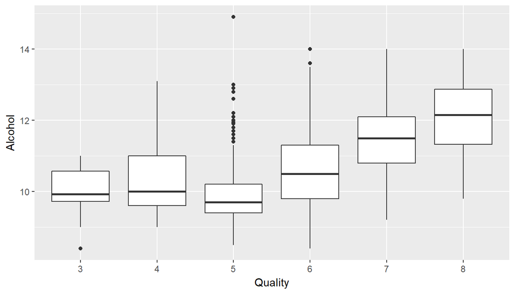

It is quite clear that as alcohol content increases,the quality rating too increses.But there are outliers present for quality rating 5.

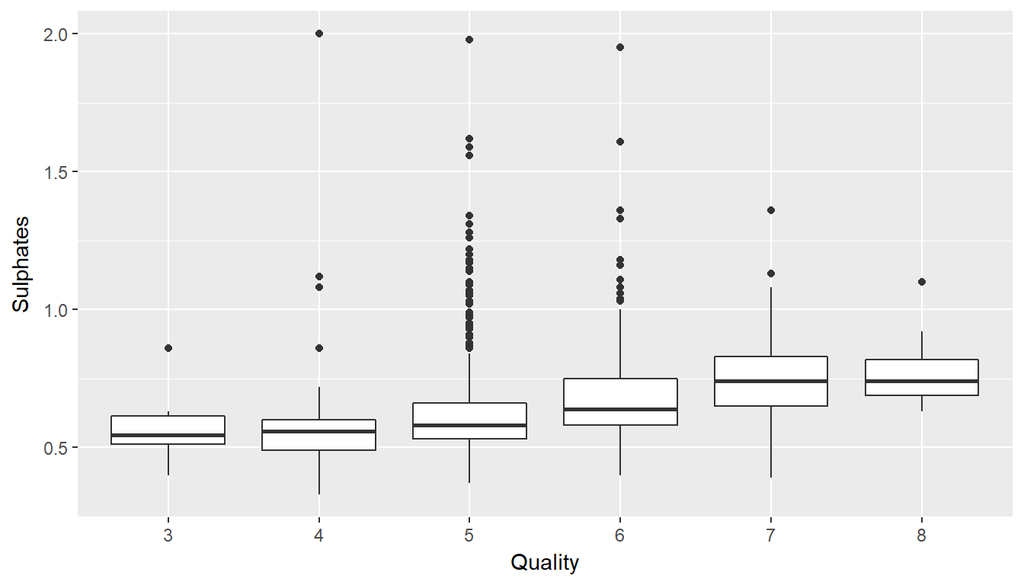

From this plot we can see that there are numerous outliers present but the overall trend remains the same i.e. quality and sulphates are positively correlated.

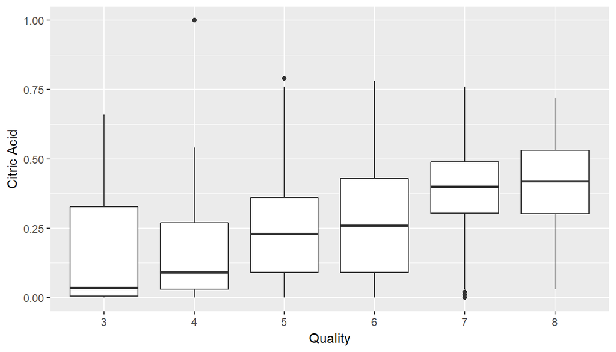

Here we hardly get to see any outliers,but the range i.e area inside the box varies.E.g-For quality rating of 3 and 4 there are more observations between median and 3rd quartile.

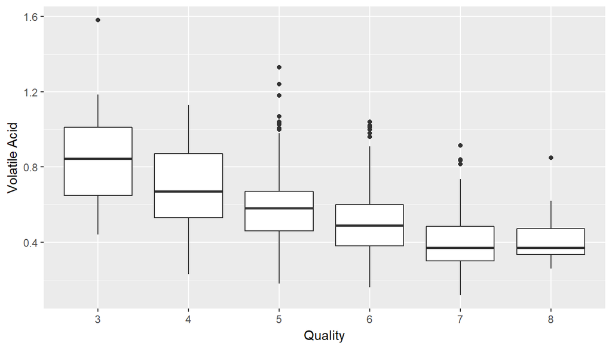

This clearly shows that the higher the volatile acidity is, the lower will our wine quality be.

# Bivariate Analysis

### Talk about some of the relationships you observed in this part of the investigation. How did the feature(s) of interest vary with other features in the dataset?

The correlation plot had clearly shown some interesting facts regarding the relationship between our feature of interest(wine) and other features like alcohol,volatile.acidity,sulphates and citric acid.While alcohol,citric acid and sulphates were positively correlated,volatile acidity was negatively correlated with quality.

### Did you observe any interesting relationships between the other features (not the main feature(s) of interest)?

Yes,there were interesting relationships between pH and fixed.acidity,pH and citric acid,total sulfur dioxide and free sulfur dioxide.The relation between pH and acid can be explained by the fact that acids have lower pH values.

### What was the strongest relationship you found?

The strongest relationships were between features which were subset of another feature.E.g-There was strong correlation between fixed acidity and citric acid, total sulfur dioxide and free sulfur dioxide.

# Multivariate Plots Section

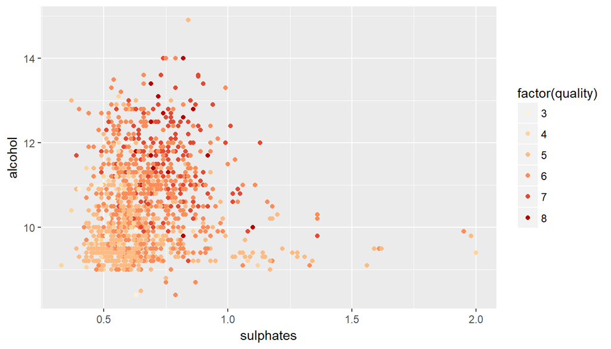

From this plot it is quite clear that higher quality(6-8) wine samples have more alcohol and sulphates than lower quality wine samples(3-5)

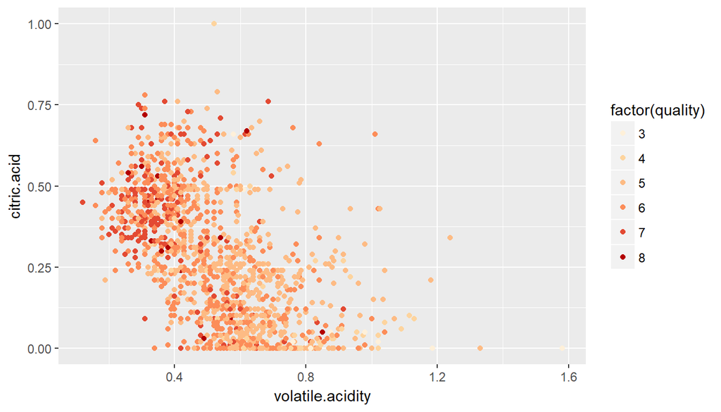

This plot sums up what we saw in bivariate analysis.The higher quality wine samples have lower volatile acidity and higher citric acid.

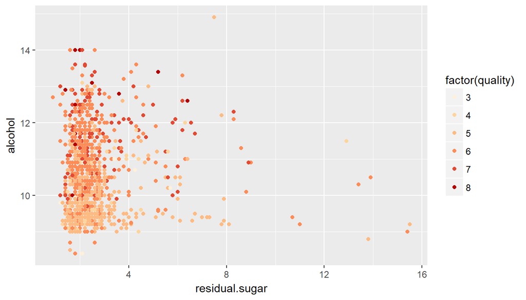

From this plot we can make conclusions about relation between alcohol and wine but it is quite clear that residual sugar is almost same for higher and lower quality wine samples.

# Multivariate Analysis

### Talk about some of the relationships you observed in this part of the investigation. Were there features that strengthened each other in terms of looking at your feature(s) of interest?

The relationships remained same.We had some idea about the relationships between our feature of interest and other features from the correlation plot.These multivariate plots just strengthened our findings from bivariate analysis.

### Were there any interesting or surprising interactions between features?

Yes,I was expecting that residual sugar will have some effect on both-alcohol and quality because of the fact that more residual sugar means less fermentation which leads to less amount of alcohol content and lower quality wine samples.But in this case,it seems residual sugar had no effect on either of these.

### OPTIONAL: Did you create any models with your dataset? Discuss the strengths and limitations of your model.

No

# Final Plots and Summary

### Plot One

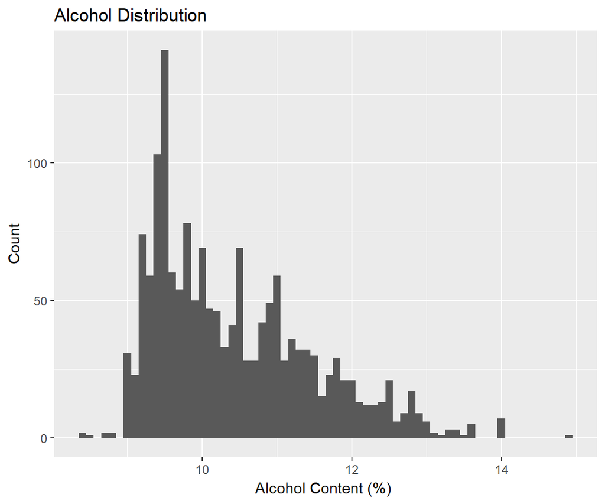

### Plot Two

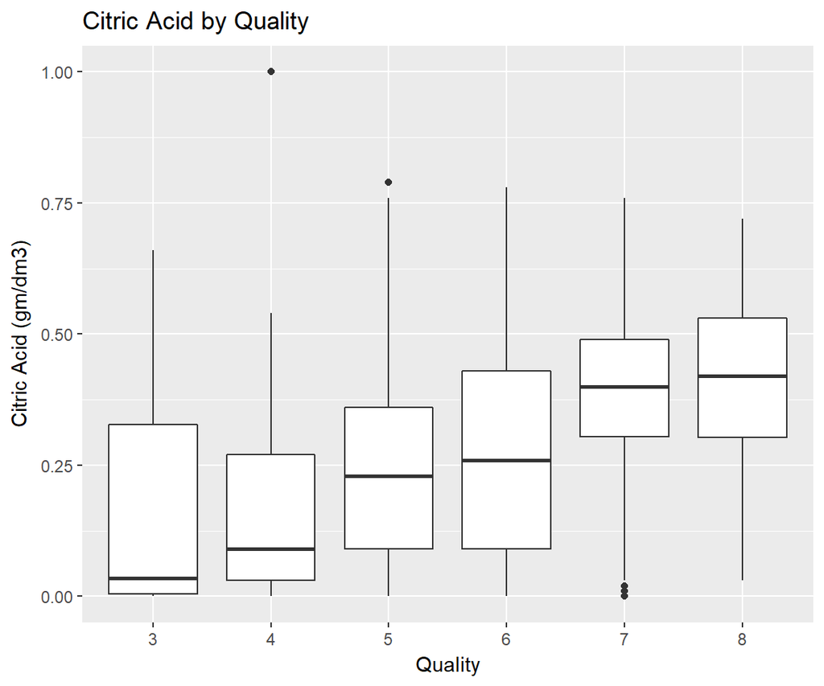

### Description Two

This plot shows that the range for each quality rating ranges differently and it is quite difficult to make any conclusions using the range.But if we look at the medians, it is quite clear that higher quality wine observations have higher median values.The reason for varied ranges could be presence of outliers in the sample.

### Plot Three

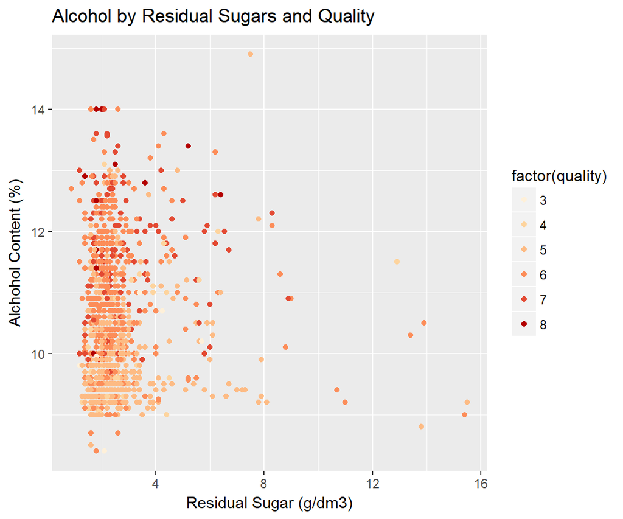

### Description Three

This plot was the most interesting one.I believed existence of higher residual sugar means the wine was not fermented properly which will in turn lead to lower alcohol quantity and thereby lower quality rating.But from the correlation plot it was quite clear that this theory was wrong.Even the above plot proves this is wrong.

# Reflection

The red wine quality dataset had 1599 rows and 13 variables.From my analysis it was clear that only few of the features were important to anlyse the quality of the wine.E.g-Alcohol content,volatile acidity,sulphates and citric acid.The rest hardly had any effect on the quality.

Successes- I was able to find some interesting facts like quality of the wine depends on the alcohol content and other chemical features like sulphates,citric acid and volatile acidity.The correlation plot made it easy for me to perform the analysis,though it took some time for me to realize why most of the acids were showing higher correlation with pH.The most surprising fact was that residual sugar had no effect on the quality of wine.

Future work that could be done on this dataset- I can create a linear model using some features like alcohol,volatile acidity,citric acid and sulphate.This then could be used to predict quality of wine.